# Project: Investigate a TMDB Dataset as part of Udacity Nanodegree program

## And let's not forget about the Casts

```python
def cast(val):

    test5 = df.sort_values(by=val, ascending=False)

    #plt.xticks(rotation = 70)

    sns.barplot(test5[val].iloc[:20], test5.cast_1.iloc[:20], palette='autumn', errwidth=0)

    params = {'figure.figsize': (18, 6), 'axes.labelsize':15, 'axes.titlesize':20}

    plt.rcParams.update(params)

    plt.title("Cast member with the highest " + val)
    plt.xlabel(val.upper(), fontsize=25)
    plt.yticks(fontsize=15)
    plt.ylabel('Actors', fontsize=25)
    plt.xticks(fontsize=15)
    plt.grid(False)
    #plt.legend(test5.cast_1.iloc[:20], title='Cast', fancybox=True)
    plt.show()
```

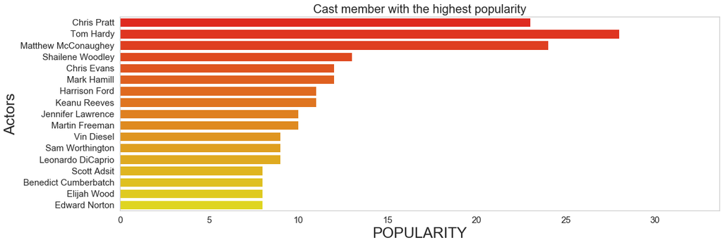

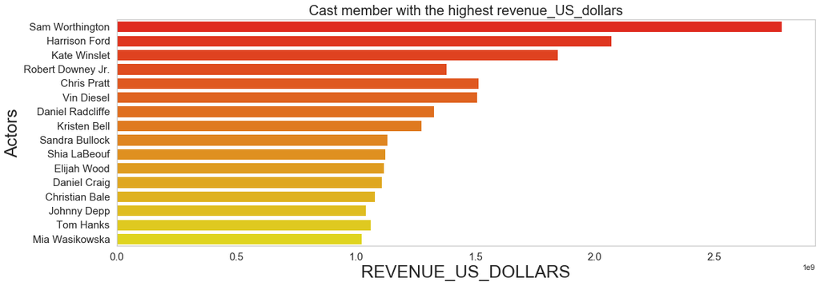

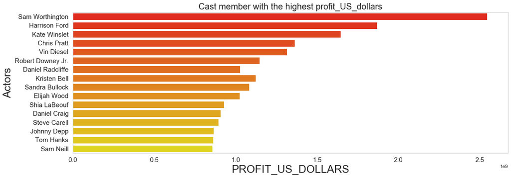

```python
cast('popularity')
cast('revenue_US_dollars')
cast('profit_US_dollars')
```

## Most Popular Actors of every decade from 1960 to 2015

```python
def cast_year(val1, val2, val3):

    a = df[df.release_year.between(val2, val3, inclusive=True)].sort_values(by=val1, ascending=False)[val1][:20]
    b = df[df.release_year.between(val2, val3, inclusive=True)].sort_values(by=val1, ascending=False)['cast_1'][:20]

    sns.barplot(a, b, palette='rocket', errwidth=False)

    params = {'figure.figsize': (20, 8), 'axes.labelsize':15, 'axes.titlesize':20}

    plt.rcParams.update(params)

    plt.title('20 most popular Actors of every decade starting from '+str(val2)+' to '+str(val3) + '\n', fontsize=30)
    plt.xlabel(val1.upper(), fontsize=25)
    plt.ylabel('Actors', fontsize=25)
    plt.yticks(fontsize=15)
```

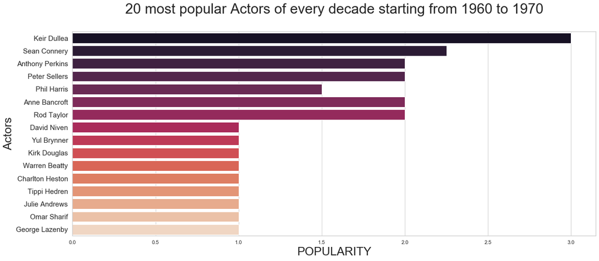

```python
cast_year('popularity', 1960, 1970)
```

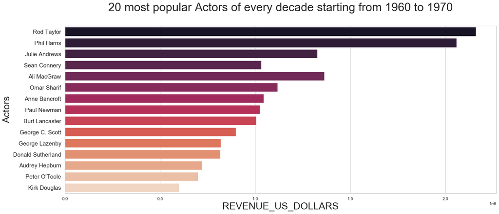

```python
cast_year('revenue_US_dollars', 1960, 1970)
```

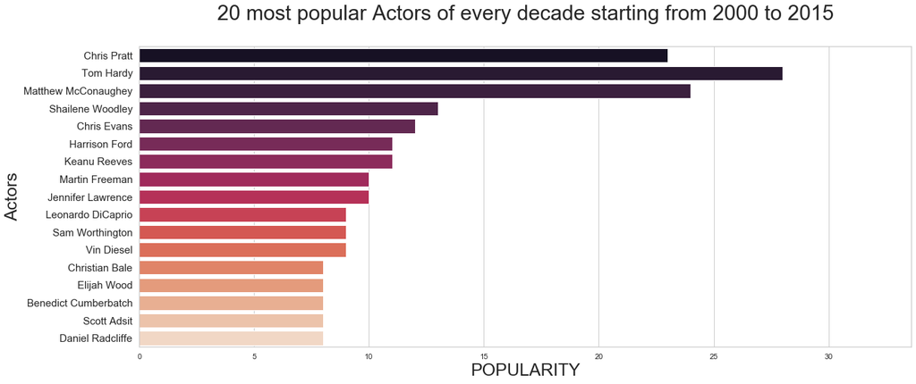

```python
cast_year('popularity', 2000, 2015)
```

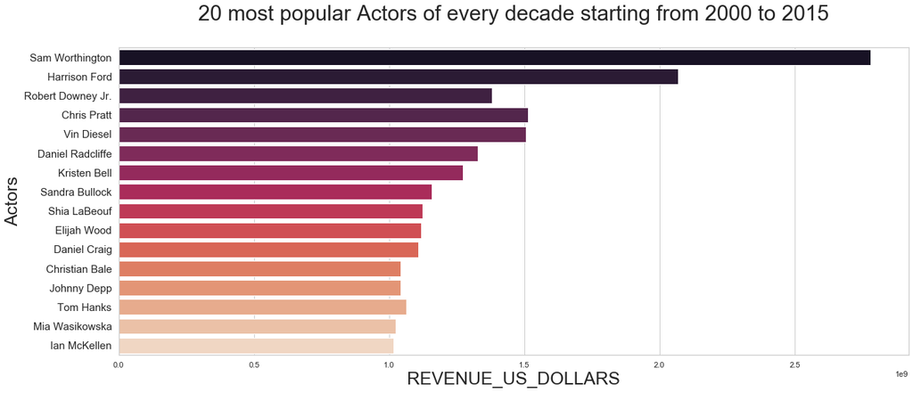

```python
cast_year('revenue_US_dollars', 2000, 2015)
```

## Top Production Companies and number of title released by them

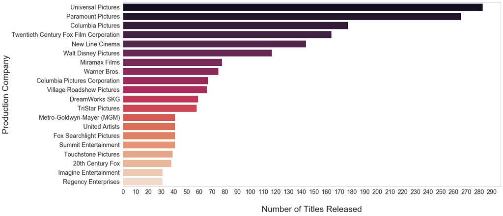

```python
prod = pd.DataFrame(df.groupby('production_companies_1', as_index=False)['original_title'].count())

prod.columns = ['Movies', 'Titles_Released']

prod = prod.sort_values(by='Titles_Released', ascending=False)[:20]

prod.reset_index(drop=True, inplace=True)

sns.set(rc={'figure.figsize':(20, 10)})
sns.set_style("whitegrid")

sns.barplot(prod.Titles_Released, prod.Movies, palette='rocket')

plt.xticks(np.arange(0, 300, 10))
plt.xlabel('\nNumber of Titles Released',fontsize=25)
plt.ylabel('Production Company',fontsize=25)
plt.xticks(fontsize=18)
plt.yticks(fontsize=18)
plt.grid(False)


plt.show()
```

## Top Production Companies across different Parameters

```python
def production(val):

    test5 = df.sort_values(by=val, ascending=False)

    #plt.xticks(rotation = 70)
    lst = []
    for i in test5[val].iloc[:30]:
        #print(i)
        if i > 1000:
            lst.append(i)
        else:
            True

    lst = sorted(lst, reverse=True)

    sns.barplot(test5.production_companies_1.iloc[:len(lst)], lst, palette='plasma', errwidth=0)

    params = {'figure.figsize': (20, 8), 'axes.labelsize':15, 'axes.titlesize':20}

    plt.rcParams.update(params)

    plt.title("Production Companies with the highest " + val)
    plt.ylabel(val)
    plt.xlabel('Production Company')

    plt.xticks(rotation=65)
    #plt.tight_layout()
    #plt.legend(test5.production_companies_1.iloc[:30], title='Production Company',
               loc='upper left', bbox_to_anchor=(0.48, 1),
                  ncol=3, fancybox=True, shadow=True)
    plt.grid(False)
    plt.show()
```

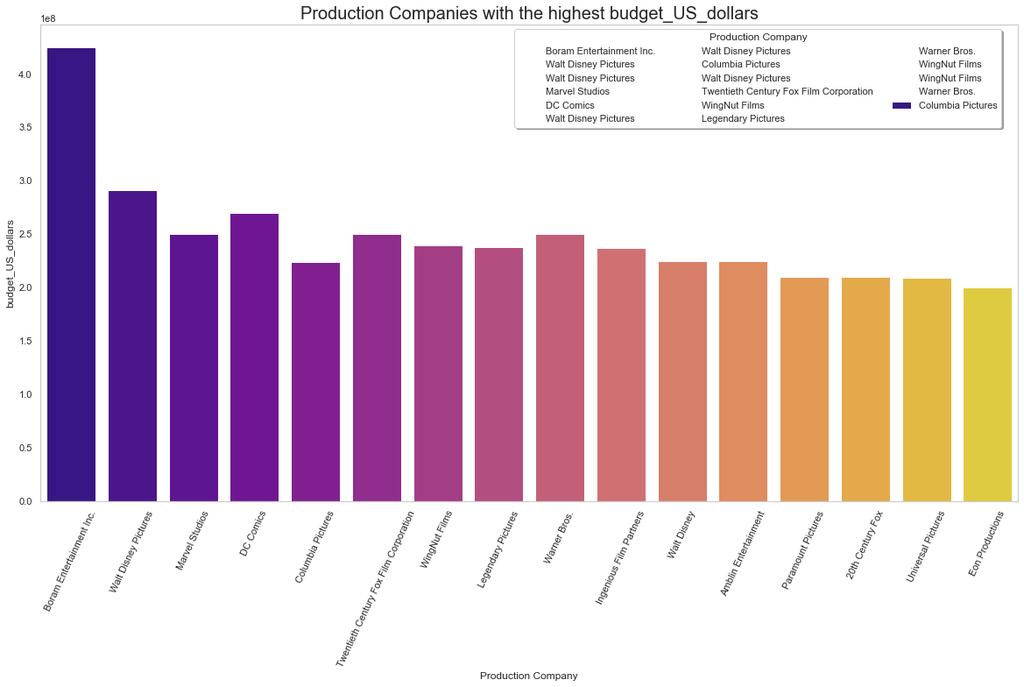

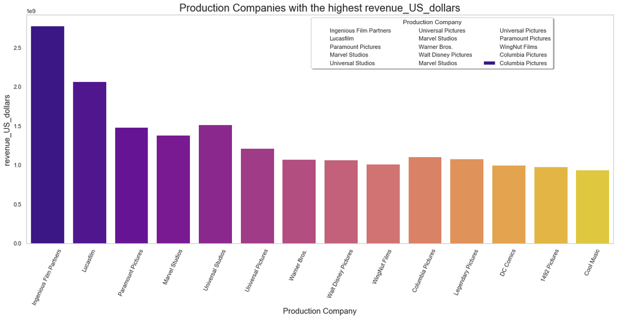

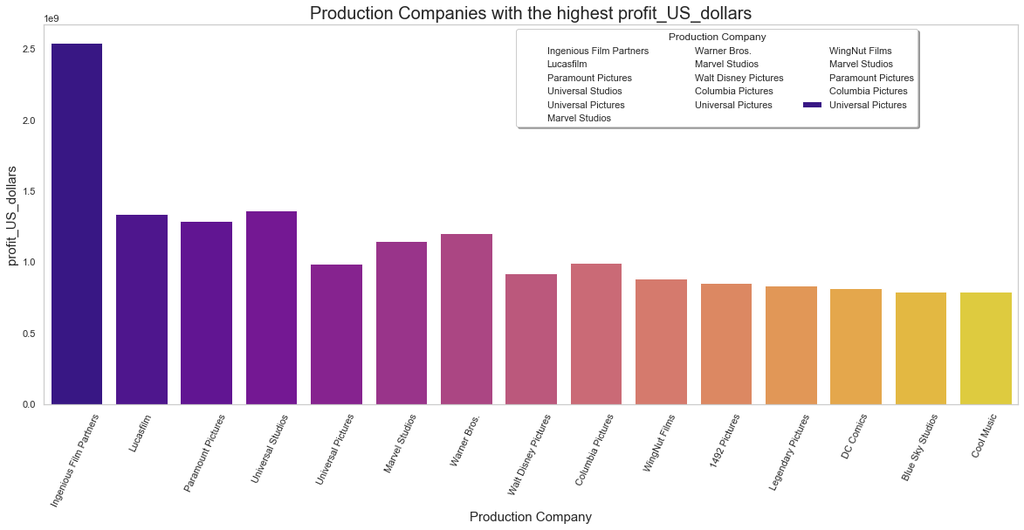

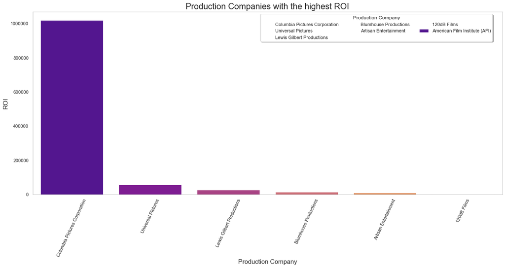

```python
production('budget_US_dollars')
production('revenue_US_dollars')
production('profit_US_dollars')
production('ROI')
```

## How is Revenue affected by the different parameters?

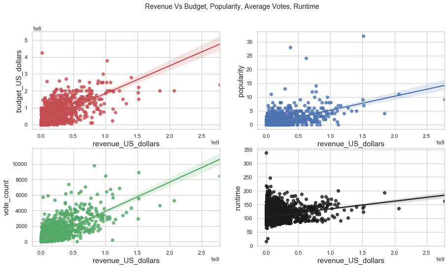

```python
fig, axes = plt.subplots(2,2,figsize = (15, 8))

fig.suptitle("Revenue Vs Budget, Popularity, Average Votes, Runtime", fontsize=14)

sns.regplot(x=df['revenue_US_dollars'], y=df['budget_US_dollars'],color='r', ax=axes[0][0])
sns.regplot(x=df['revenue_US_dollars'], y=df['popularity'],color='b', ax=axes[0][1])
sns.regplot(x=df['revenue_US_dollars'], y=df['vote_count'],color='g', ax=axes[1][0])
sns.regplot(x=df['revenue_US_dollars'], y=df['runtime'],color='k', ax=axes[1][1])

sns.set_style("whitegrid")
```

## Research Questions:

1. **How is the film making industry evolving?**

   **- How much more movies people are consuming now compared to last few decades? (Growth Rate)**

   These are the growth rates compared on a 20-year basis.

   It is evident that number of movies produced has sky-rocketed rapidly through the years based on the following growth rate figures:

   From 1960 -> 1980: It has increased about 340% From 1980 -> 2000: It increased 378% From 2000 -> 2015: It increased 92%

   **- Is movie making a profitable business?**

   We can see from the graph that from 2000 onwards, the budget that goes into making movies was almost constant whereas the Revenue and Profit rose significantly thus proving that movie making is a highly profitable industry. A steady investment seems to yield growing revenues and profits.

   **- What are the some of the best and the not-so-good performing movies across different parameters through the years?**

   Talk about tanking at the box office.

   There’s a movie with runtime of 338mins while there’s also a movie with runtime of 15mins! These are easily very distinct outliers. Jurassic World is the most popular movie while the Karate Kid part2 is the movie which has given the highest ROI.
2. **Does runtime hold any importance? What is the preferred runtime of viewers?**

   **- How has the average runtime of movies changed over the years?**

   Studies suggest that in a short span of 15 years, an average human’s attention span has reduced from 12secs to around 8secs! We now have an attention span which is less than that of a goldfish! Go figure.

   This has an implication for movie makers as audience would now demand more narrow, focused, targeted and crisp content.

   Which as seen from the trend curve of Movie runtimes through the years, it’s evident that movies are also reflecting the change. The runtime has gone down from the highest count of around 170mins in 1965 to around 110mins in the period between 2000 to 2015.

   **- What is the Average Runtime of movies currently?**

   From the boxplots, it is evident that that the average runtime of movie varies between ~96min to ~120max with outliers at ~250mins, ~350mins and ~15mins. From the violin plot, we can see that most movies have a runtime between 90 to 110mins as distribution of movies around that range is maximum.

   **- Is there any visible relationship between Revenue and Popularity with Runtime?**

   From the two Histograms of Revenue vs Runtime and Popularity vs Runtime, it is clear that movies between runtime of 140-150mins brings the most moolah and movies between 140-145mins are the most popular.

   So runtime seems to have a significant impact on Revenue and Popularity.

   However, there’s a contradiction where movies between 115-125mins seem to be very popular among viewers but they are bringing very less revenue to producers.

   If we look at the Avg. Runtime comparison of Movie Genres, we can see that the genres - War, History and Western fits the description of genres between 115-125 mins. Also, if we look at the popularity distribution of these genres, we can see that they are relatively quite popular.

   Now if we compare the revenue brought in by these 3 genres, we can see all 3 genres score very low in Revenue. So, we might conclude that although Western, War and History movies are popular among viewers, they don’t bring as much revenue as they should.
1. **What are The top 10 movies of the world based on different parameters?**

   The plot of top 10 movies futher explores the movies based on different parameters.

   Based on popularity index, most movies are recent releases with Jurassic World leading the table.

   The movie with the highest budget i.e. The Warrior’s way is followed by mostly newer movies. Since overall, the budget figures are lesser for 2000-2015, it can be assumed that the movies in the list must have had a significant budget over their counter-parts to top the list.

   The movie which made the highest profits are Avatar, Star wars and Titanic with 2 of those movies being directed by James Cameron.

   The movie with the highest runtime can easily be considered epics with Carlos and Cleopatra having runtimes of 350 and 250mins approx respectively!

   The movie with highest ROI is The karate Kid part2 which far surpasses its counterparts in that category.
1. **Genres**

   **- What are the main movie genres and distribution of movies across genres?**

   **Genres-Popularity over the years**

   **1960-1980:** From 1960-1980, the film genres that were most popular were Adventure, Animation and Mystery. Surprisingly, there was a huge popularity of Foreign Movies during this period.

   **1980-2000:** This period saw the emergence of War and Western movies among the popular Genres. Animation continued to lead with Science fiction also emerging as the new favourite.

   **2000-2015:** During this period, almost all genres saw a boom in popularity with Adventure, Fantasy and Science Fiction sky-rocketing! Foreign films unfortunately didn’t rise in popularity after 1980s.

   Hence, we can see that non-popular genres like Fantasy, Science Fiction and Animation movies have evolved through the years and have actually become popular among audiences. However, genres like Foreign Films took a backtrack and eventually disappeared from the popular list.

   **- How do different Genres perform across different parameters?**

   **Genres(Runtime)**

   Looking at the distribution of runtime for various genres, we can see that Western, War and history movies have the highest runtimes among all the genres, followed by Drama, Action and adventure. Animation and T.V. movies are among the lowest spectrum of runtimes.

   **Genres(Popularity)**

   Looking at the popularity scores of Genres, Adventure, Fantasy and Science Fiction seems to be the most popular genres followed by Animation, Family and Action.

   **Genres(Budget, Revenue and Profit)**

   As seen from a previous plot, Budget of movies has been in a steady while revenue and profit figures are higher for a given budget invested.

   The Genres which get the most investment are Action, Adventure, Animation followed by Family and Fantasy. And why wouldn’t producers be unhappy with it, the revenue and profits seem almost proportional to the budget invested in almost all Genres except Foreign genre movies which seem to have a negative profit! Sigh! The audience doesn’t seem to appreciate Foreign movies much.
1. **Who are the most successful movie directors and film stars?**

   Some of the top directors in terms of Revenue and profit generation abilities are also very popular and have high vote counts with a few exceptions.

   Movies which have very high ratings have directors with high ratings too.

   If we compare decade wise, we can see some interesting figures. For e.g. in 1970-1979, George Lucas with his glorious Star Wars franchise far exceeds any other directors in terms of popularity. Similarly, during 2000-2009, James Cameron with movies like Terminator and Avatar is the most popular director of that decade.

   Among the modern directors, Colin Trevorrow and George Miller are the most popular directors.

   Among the casts, Sam Worthington brings in the most revenue and is most profitable although on a popularity basis, he doesn’t rate very high on the list.

   Popularity doesn’t always mean a high revenue and profitability and vice-versa, a trend which was seen in the case of the top directors too.
1. **Does having the most popular director or actor ensure financial success in the box office?**

   The top production companies of the world are Universal pictures, Paramount pictures and Columbia pictures with 280, 270 and 180 movies produced respectively!

   These production companies do not feature on the top 3 production houses with most budget though with Universal and Paramount on the far end of the spectrum suggesting that these houses might be rolling out a lot of low budget movies, quantity over quality perhaps.

   Or perhaps, Walt Disney, Marvel and DC with their superhero movies may be needing to put more money on the bag to produce their genre of movies.

   Columbia pictures Corp. Have the highest ROI figures far exceeding rivals suggesting that they excel in churning out the maximum profit with the minimum investment.
1. **How does Revenue depend on different parameters?**

## Resources

https://numpy.org/

https://docs.scipy.org/doc/numpy/reference/

https://pandas.pydata.org/

https://pandas.pydata.org/docs/

https://seaborn.pydata.org/

https://www.imdb.com/list/ls003027246/

https://seaborn.pydata.org/generated/seaborn.pointplot.html

https://seaborn.pydata.org/generated/seaborn.lmplot.html